[figure not shown]

# Manipulación, exploración y calidad de datos

En este notebook tutorial aprenderás cómo explorar un conjunto de datos con la ayuda de la librería Pandas. También usaremos librerías de visualización de datos muy útiles para conocer los datos, como Matplotlib y Seaborn.

En este notebooks verás cómo:

1. Importar las librerías que usaremos.
2. Cargar un conjunto de datos.
3. Describir los datos.
4. Manipular los datos.
5. Generar distintos tipos de visualizaciones.
6. Verificar la calidad de datos.

El conjunto de datos que usaremos a lo largo de este notebook recopila información sobre la venta de inmuebles, la cual incluye variables que describen las características principales de cada uno y el precio final de venta. El análisis de estos datos puede ser útil para comprender los factores que influyen en el valor de mercado de los inmuebles y para construir modelos predictivos para este sector.

## 1. Importar las librerías que usaremos

Como primer paso vamos a importar las librerías con las que vamos a trabajar. Primero, veamos la función de cada una:

- Pandas: nos permite cargar, explorar y manipular grandes conjuntos de datos.
- Matplotlib: nos ayuda a crear visualizaciones y gráficos personalizados.
- Seaborn: facilita la creación de gráficos estadísticos.

```python
import pandas as pd
import matplotlib.pyplot as plt
import seaborn as sns
```

Luego, revisamos las versiones de las librerías a usar. Esto es útil para asegurar la compatibilidad del código y reproducibilidad de resultados en otros entornos, localmente o en Google Colab, evitando errores inesperados. Además, sirve para revisar la documentación adeduada porque puede cambiar con el tiempo.

```python
from importlib.metadata import version
print(f"Versión de Pandas: {version('pandas')}")
print(f"Versión de Matplotlib: {version('matplotlib')}")
print(f"Versión de Seaborn: {version('seaborn')}")
```

```
Versión de Pandas: 2.1.4
Versión de Matplotlib: 3.8.0
Versión de Seaborn: 0.12.2
```

## 2. Cargar un conjunto de datos

A continuación, vamos a cargar el conjunto de datos que utilizaremos. Este archivo se encuentra en formato Excel, que al igual que el CSV, es un formato ampliamente utilizado para almacenar datos tabulares. Para leerlo usaremos la función de Pandas `read_excel()`. Es importante aclarar que al interior de los paréntesis se especifica la ruta en la cual se encuentra el conjunto de datos, en este caso localizaremos el archivo en el subdirectorio `data`, que se encuentra en el mismo directorio de este notebook. Si el conjunto tiene una ubicación diferente, puedes cambiar la ruta al interior de los paréntesis o modificar la ubicación del archivo.

En caso de que el conjunto de datos se encuentre en formato CSV, usaremos la función `read_csv()`.

```python
datos_inmuebles = pd.read_excel('./data/Venta_Inmuebles.xlsx', )
```

Con esta sentencia, el archivo Excel se transforma en un DataFrame, una estructura compuesta de filas y columnas. La librería de Pandas, nos ayuda a estructurar los datos de esta forma para facilitar su exploración, manipulación y análisis de los datos.

Una buena práctica es trabajar siempre con una copia de los datos:

```python
data = datos_inmuebles.copy()
```

Para tener una primera visión de los datos usaremos la función head(), la cual nos permite ver los primeros cinco registros del DataFrame:

```python
data.head()
```

|  | Id | Fecha | Precio | Cuartos | Baños | AreaHabitable | AreaLote | Pisos | FrenteMar | Vista | ... | Calificación | AreaSuperior | AreaBase | Años | Renovación | CodigoPostal | Latitud | Longitud | AreaHabitable15 | AreaLote15 |
| --- | --- | --- | --- | --- | --- | --- | --- | --- | --- | --- | --- | --- | --- | --- | --- | --- | --- | --- | --- | --- | --- |
| 0 | 7129300520 | 20141013T000000 | 221900.0 | 3 | 1.00 | 1180 | 5650 | 1.0 | NO | 0 | ... | 7.0 | 1180 | 0 | 1955 | 0 | 98178 | 475112.0 | -122257.0 | 1340 | 5650 |
| 1 | 6414100192 | 20141209T000000 | 538000.0 | 3 | 2.25 | 2570 | 7242 | 2.0 | NO | 0 | ... | 7.0 | 2170 | 400 | 1951 | 1991 | 98125 | 47721.0 | -122319.0 | 1690 | 7639 |
| 2 | 5631500400 | 20150225T000000 | 180000.0 | 2 | 1.00 | 770 | 10000 | 1.0 | NO | 0 | ... | 6.0 | 770 | 0 | 1933 | 0 | 98028 | 477379.0 | -122233.0 | 2720 | 8062 |
| 3 | 2487200875 | 20141209T000000 | 604000.0 | 4 | 3.00 | 1960 | 5000 | 1.0 | NO | 0 | ... | 7.0 | 1050 | 910 | 1965 | 0 | 98136 | 475208.0 | -122393.0 | 1360 | 5000 |
| 4 | 1954400510 | 20150218T000000 | 510000.0 | 3 | 2.00 | 1680 | 8080 | 1.0 | NO | 0 | ... | 8.0 | 1680 | 0 | 1987 | 0 | 98074 | 476168.0 | -122045.0 | 1800 | 7503 |

5 rows × 21 columns

Aquí podemos entender lo que se espera que se encuentre en el resto de los registros y también, el formato en el que se encuentran.

También, podemos ver registros aleatorios del dataset, con el objetivo de profundizar un poco más y ver que los registros de cualquier posición cumplen con el formato:

```python
display(data.sample(5))
```

|  | Id | Fecha | Precio | Cuartos | Baños | AreaHabitable | AreaLote | Pisos | FrenteMar | Vista | ... | Calificación | AreaSuperior | AreaBase | Años | Renovación | CodigoPostal | Latitud | Longitud | AreaHabitable15 | AreaLote15 |
| --- | --- | --- | --- | --- | --- | --- | --- | --- | --- | --- | --- | --- | --- | --- | --- | --- | --- | --- | --- | --- | --- |
| 19375 | 8900000100 | 20141231T000000 | 509000.0 | 4 | 2.0 | 1630 | 1724 | 1.5 | NO | 0 | ... | 6.0 | 1030 | 600 | 1915 | 1970 | 98119 | 476472.0 | -122362.0 | 1780 | 3810 |
| 1538 | 4279200060 | 20141230T000000 | 420000.0 | 4 | 2.5 | 2110 | 9825 | 2.0 | NO | 0 | ... | 8.0 | 2110 | 0 | 2000 | 0 | 98059 | 474979.0 | -122153.0 | 1650 | 9900 |
| 7411 | 926069132 | 20140520T000000 | 450000.0 | 3 | 1.5 | 2060 | 44866 | 1.0 | NO | 0 | ... | 8.0 | 2060 | 0 | 1953 | 0 | 98077 | 477503.0 | -122051.0 | 2320 | 43995 |
| 587 | 7504010570 | 20140708T000000 | 900000.0 | 3 | 2.5 | 3180 | 12600 | 2.0 | NO | 0 | ... | 11.0 | 3180 | 0 | 1978 | 0 | 98074 | 476366.0 | -122058.0 | 3030 | 12835 |
| 15650 | 2599000130 | 20140716T000000 | 247200.0 | 3 | 1.0 | 1590 | 11200 | 1.0 | NO | 0 | ... | 7.0 | 1590 | 0 | 1961 | 0 | 98092 | 472894.0 | -122188.0 | 1560 | 9750 |

5 rows × 21 columns

Adicionalmente, podemos conocer el tamaño del conjunto de datos, es decir, conocer el número de columnas y filas. Para ello usamos la función `shape`:

```python
data.shape
```

```
(21613, 21)
```

Esto nos dice que el conjunto de datos está compuesto por 21.613 registros (filas) y 21 variables (columnas).

Otra funcionalidad que nos permite Pandas, es el de conocer el tipo de dato de cada columna, para ello usamos `data.info()`.

```python
data.info()
```

```
<class 'pandas.core.frame.DataFrame'>
RangeIndex: 21613 entries, 0 to 21612
Data columns (total 21 columns):
 #   Column           Non-Null Count  Dtype
---  ------           --------------  -----
 0   Id               21613 non-null  int64
 1   Fecha            21613 non-null  object
 2   Precio           21613 non-null  float64
 3   Cuartos          21613 non-null  int64
 4   Baños            21613 non-null  float64
 5   AreaHabitable    21613 non-null  int64
 6   AreaLote         21613 non-null  int64
 7   Pisos            21613 non-null  float64
 8   FrenteMar        21613 non-null  object
 9   Vista            21613 non-null  int64
 10  Condición        21613 non-null  int64
 11  Calificación     21607 non-null  float64
 12  AreaSuperior     21613 non-null  int64
 13  AreaBase         21613 non-null  int64
 14  Años             21613 non-null  int64
 15  Renovación       21613 non-null  int64
 16  CodigoPostal     21613 non-null  int64
 17  Latitud          21613 non-null  float64
 18  Longitud         21613 non-null  float64
 19  AreaHabitable15  21613 non-null  int64
 20  AreaLote15       21613 non-null  int64
dtypes: float64(6), int64(13), object(2)
memory usage: 3.5+ MB
```

Es interesante ver que las únicas columnas que no son numéricas (int o float) son `Fecha` y `FrenteMar`, las cuales están en formato object, esto es algo importante y que debemos tener en cuenta.

Un insumo imprescindible para entender un conjunto de datos es el diccionario, ya que este nos permite conocer el significado de cada varoable y sus rangos válidos.

```python
dict = pd.read_excel('./data/diccionario_Venta_Inmuebles.xlsx')
pd.set_option('display.max_colwidth', None)
dict
```

|  | Variable | Tipo | Descripción |
| --- | --- | --- | --- |
| 0 | ID | int64 | Identificador único de la transacción o propiedad. |
| 1 | Fecha | object | Fecha y hora de registro de la venta en formato AAAAMMDDThhmmss. |
| 2 | Precio | float64 | Precio de venta final en unidades monetaria. |
| 3 | Cuartos | int64 | Número de dormitorios de la vivienda. Valores más altos indican mayor capacidad. No confundir con espacios abiertos (estudios). |
| 4 | Baños | float64 | Número de baños. Puede incluir medios baños (0.5). Se usa como indicador de confort y capacidad del inmueble. |
| 5 | AreaHabitable | int64 | Área interior habitable en pies². |
| 6 | AreaLote | int64 | Área total del terreno en pies². |
| 7 | Pisos | float64 | Cantidad de pisos de la vivienda. Puede tomar valores fraccionarios (ej. 1.5 niveles). |
| 8 | FrenteMar | Categórica | Indicador de frente o acceso directo al agua (Sí, No). Suele asociarse con primas de precio. |
| 9 | Vista | int64 | Índice ordinal de calidad de la vista (0 = sin vista, 4 = excelente). |
| 10 | Condición | int64 | Estado físico general (1 = muy mala, 5 = excelente). Representa mantenimiento/antigüedad funcional. |
| 11 | Calificación | int64 | Calidad del diseño y construcción (1 = muy baja, 13 = lujo). Escala basada en estándares de tasación locales. |
| 12 | AreaSobreSuelo | int64 | Área habitable sobre el nivel del suelo en pies². |
| 13 | AreaSótano | int64 | Área de sótano en pies². Puede ser 0 si no existe. |
| 14 | Años | int64 | Año de construcción original de la vivienda. |
| 15 | Renovación | int64 | Año de la última renovación. Valor 0 indica que no ha sido renovada. |
| 16 | CódigoPostal | int64 | Código postal. |
| 17 | Latitud | float64 | Latitud geográfica en grados decimales (WGS84). |
| 18 | Longitud | float64 | Longitud geográfica en grados decimales (WGS84). |
| 19 | AreaHabitable15 | int64 | Promedio del área habitable (pies²) de las 15 viviendas cercanas. Aproxima el tamaño promedio del vecindario. |
| 20 | AreaLote15 | int64 | Promedio del área del lote (pies²) de las 15 viviendas cercanas. Indica densidad/tamaño de parcelas cercanas. |

## 3. Descripción de los datos

Con el objetivo de tener una descripción más clara de los datos usamos la función `describe()`, la cual nos permite obtener mediciones estadísticas que nos ayudarán en el análisis, como lo son la media, la desviación estándar, el mínimo, el máximo y una separación por cuartiles, para las variables numéricas.

```python
data.describe()
```

|  | Id | Precio | Cuartos | Baños | AreaHabitable | AreaLote | Pisos | Vista | Condición | Calificación | AreaSuperior | AreaBase | Años | Renovación | CodigoPostal | Latitud | Longitud | AreaHabitable15 | AreaLote15 |
| --- | --- | --- | --- | --- | --- | --- | --- | --- | --- | --- | --- | --- | --- | --- | --- | --- | --- | --- | --- |
| count | 2.161300e+04 | 2.161300e+04 | 21613.000000 | 21613.000000 | 21613.000000 | 2.161300e+04 | 21613.000000 | 21613.000000 | 21613.000000 | 21607.000000 | 21613.000000 | 21613.000000 | 21613.000000 | 21613.000000 | 21613.000000 | 21613.000000 | 21613.000000 | 21613.000000 | 21613.000000 |
| mean | 4.580302e+09 | 5.401822e+05 | 3.370842 | 2.114757 | 2079.899736 | 1.510697e+04 | 1.494309 | 0.247397 | 3.409430 | 7.656500 | 1788.390691 | 291.509045 | 1971.005136 | 84.402258 | 98077.939805 | 430610.744655 | -109898.947043 | 1986.552492 | 12768.455652 |
| std | 2.876566e+09 | 3.673622e+05 | 0.930062 | 0.770163 | 918.440897 | 4.142051e+04 | 0.539989 | 1.100329 | 0.650743 | 1.174463 | 828.090978 | 442.575043 | 29.373411 | 401.679240 | 53.505026 | 132157.751849 | 36768.975764 | 685.391304 | 27304.179631 |
| min | 1.000102e+06 | 7.500000e+04 | 0.000000 | 0.000000 | 290.000000 | 5.200000e+02 | 1.000000 | -3.000000 | 1.000000 | 1.000000 | 290.000000 | 0.000000 | 1900.000000 | 0.000000 | 98001.000000 | 47.190000 | -122519.000000 | 399.000000 | 651.000000 |
| 25% | 2.123049e+09 | 3.219500e+05 | 3.000000 | 1.750000 | 1427.000000 | 5.040000e+03 | 1.000000 | 0.000000 | 3.000000 | 7.000000 | 1190.000000 | 0.000000 | 1951.000000 | 0.000000 | 98033.000000 | 473849.000000 | -122318.000000 | 1490.000000 | 5100.000000 |
| 50% | 3.904930e+09 | 4.500000e+05 | 3.000000 | 2.250000 | 1910.000000 | 7.618000e+03 | 1.500000 | 0.000000 | 3.000000 | 7.000000 | 1560.000000 | 0.000000 | 1975.000000 | 0.000000 | 98065.000000 | 475524.000000 | -122205.000000 | 1840.000000 | 7620.000000 |
| 75% | 7.308900e+09 | 6.450000e+05 | 4.000000 | 2.500000 | 2550.000000 | 1.068800e+04 | 2.000000 | 0.000000 | 4.000000 | 8.000000 | 2210.000000 | 560.000000 | 1997.000000 | 0.000000 | 98118.000000 | 476694.000000 | -122062.000000 | 2360.000000 | 10083.000000 |
| max | 9.900000e+09 | 7.700000e+06 | 33.000000 | 8.000000 | 13540.000000 | 1.651359e+06 | 3.500000 | 44.000000 | 5.000000 | 13.000000 | 9410.000000 | 4820.000000 | 2015.000000 | 2015.000000 | 98199.000000 | 477776.000000 | -121.480000 | 6210.000000 | 871200.000000 |

Esta descripción de los datos nos ayuda mucho a entenderlos sin la necesidad de recorrerlos por completo. Por ejemplo, ahora sabemos que el número mínimo de `Cuartos` es 0, su número máximo es 33 y la media es de 3,37.

Adicionalmente, si deseamos conocer el número de veces que un valor aparece en una determinada columna, podemos usar la función `value_counts()`. Para ejemplificarlo, vamos a ver cuántos inmuebles están frente al mar y cuántos no.

```python
data['FrenteMar'].value_counts()
```

```
FrenteMar
NO    21446
SI      163
no        4
Name: count, dtype: int64
```

## 4. Manipulación de los datos

En muchas ocasiones es necesario trabajar con un subconjunto del DataFrame, ya sea para responder a algunas preguntas sobre los datos o porque queremos optimizar tiempo y recursos.

### Selección de filas

La librería de Pandas, mediante a la función `data.iloc[]` permite seleccionar registros dependiendo de su posición en el DataFrame, esto se hace por índices, por lo que para consultar la primera fila lo hacemos con 0, para la última con n-1 (siendo n el número de filas) y siguiendo esa misma lógica para los demás. Por ejemplo, para ver el dato 100, el índice debe ser 99:

```python
data.iloc[99]
```

```
Id                      7338200240
Fecha              20140516T000000
Precio                    437500.0
Cuartos                          3
Baños                          2.5
AreaHabitable                 2320
AreaLote                     36847
Pisos                          2.0
FrenteMar                       NO
Vista                            2
Condición                        3
Calificación                   9.0
AreaSuperior                  2320
AreaBase                         0
Años                          1992
Renovación                       0
CodigoPostal                 98045
Latitud                   474838.0
Longitud                 -121714.0
AreaHabitable15               2550
AreaLote15                   35065
Name: 99, dtype: object
```

Sin embargo, lo anterior no solo aplica a la visualización de un único registro, sino también a conjuntos consecutivos de datos. Para ello se utiliza el operador : (slicing). Al indicar un intervalo x:y, la función selecciona los registros desde la posición x hasta y-1. Por esta razón, si se desea incluir el registro ubicado en la posición y, es necesario especificar el intervalo como x:y+1. Por ejemplo, para obtener los datos comprendidos entre las posiciones 100 y 105, se debe utilizar la siguiente expresión:

```python
data.iloc[99:105]
```

|  | Id | Fecha | Precio | Cuartos | Baños | AreaHabitable | AreaLote | Pisos | FrenteMar | Vista | ... | Calificación | AreaSuperior | AreaBase | Años | Renovación | CodigoPostal | Latitud | Longitud | AreaHabitable15 | AreaLote15 |
| --- | --- | --- | --- | --- | --- | --- | --- | --- | --- | --- | --- | --- | --- | --- | --- | --- | --- | --- | --- | --- | --- |
| 99 | 7338200240 | 20140516T000000 | 437500.0 | 3 | 2.50 | 2320 | 36847 | 2.0 | NO | 2 | ... | 9.0 | 2320 | 0 | 1992 | 0 | 98045 | 474838.0 | -121714.00 | 2550 | 35065 |
| 100 | 1952200240 | 20140611T000000 | 850830.0 | 3 | 2.50 | 2070 | 13241 | 1.5 | NO | 0 | ... | 9.0 | 1270 | 800 | 1910 | 0 | 98102 | 476415.0 | -122315.00 | 2200 | 4500 |
| 101 | 5200100125 | 20141027T000000 | 555000.0 | 3 | 2.00 | 1980 | 3478 | 1.5 | NO | 0 | ... | 7.0 | 1440 | 540 | 1929 | 0 | 98117 | 476775.0 | -122372.00 | 1610 | 3478 |
| 102 | 7214720075 | 20141212T000000 | 699950.0 | 3 | 2.25 | 2190 | 107593 | 2.0 | NO | 0 | ... | 8.0 | 2190 | 0 | 1983 | 0 | 98077 | 477731.0 | -122.08 | 2570 | 47777 |
| 103 | 2450000295 | 20141007T000000 | 1090000.0 | 3 | 2.50 | 2920 | 8113 | 2.0 | NO | 0 | ... | 8.0 | 2920 | 0 | 1950 | 2010 | 98004 | 475814.0 | -122196.00 | 2370 | 8113 |
| 104 | 6197800045 | 20140924T000000 | 290000.0 | 3 | 1.00 | 1210 | 33919 | 1.0 | NO | 0 | ... | 7.0 | 1210 | 0 | 1954 | 0 | 98058 | 474375.0 | -122184.00 | 1640 | 14910 |

6 rows × 21 columns

#### **Ejercicios**

1. Selecciona las filas de posición 10 a 19 (ten presente los índices).
2. Selecciona las últimas 5 filas usando índices negativos.
3. Selecciona los registros en posiciones pares entre los índices 10 y 20 (Pista: usa nuevamente el operador `:` nuevamente al interior de la función `iloc()`)

```python
# Punto 1
print("PUNTO 1")

# Punto 2
print("PUNTO 2")

# Punto 3
print("PUNTO 3")
```

### Selección de columnas

Al igual que hicimos con las filas, también es posible seleccionar columnas específicas del DataFrame, para ello usaremos `data.loc[]`, que nos permite obtener las variables que deseemos del conjunto de datos. Esta función requiere de dos parámetros, el primero es el número de datos que se quieren tener y el segundo, la variable que queremos seleccionar. Es importante detallar el papel que juega el operador `:`, ya que este indica que se van a seleccionar todas las filas.

**Aclaración:** es importante tener cuidado con el nombre de las funciones, ya que para las filas usamos la función `iloc[]`, pero ahora para las columnas usaremos la función `loc[]`.

Por ejemplo, si se quiere seleccionar la variable "Cuartos":

```python
data.loc[:,'Cuartos']
```

```
0        3
1        3
2        2
3        4
4        3
        ..
21608    3
21609    4
21610    2
21611    3
21612    2
Name: Cuartos, Length: 21613, dtype: int64
```

Otra forma de hacer lo mismo que hicimos arriba es usando el índice de esa columna, pero en este caso tendríamos que trabajar nuevamente con la función `iloc[]`.

Para obtener lo mismo del ejemplo anterior, usamos el índice de la columna `Cuartos` que es 3:

```python
data.iloc[:, 3]
```

```
0        3
1        3
2        2
3        4
4        3
        ..
21608    3
21609    4
21610    2
21611    3
21612    2
Name: Cuartos, Length: 21613, dtype: int64
```

Esta técnica no se limita únicamente a una sola variable, también podemos obtener varias columnas en una sola operación. Para ello debemos tener un arreglo con las etiquetas de las columnas que queremos usar. Para esto, nuevamente usamos la función `loc[]`, teniendo como segundo parámetro el arreglo de las columnas. Para extraer los registros con las columnas `Precio` y `Cuartos` tenemos lo siguiente:

```python
data.loc[:,['Precio','Cuartos']]
```

#### **Ejercicios**

1. Selecciona las columnas de la posición 2 a 4 (en total debes tener 3 columnas).
2. Trae las siguientes columnas en este mismo orden: (`id`, `yr_built`, `bedrooms`, `bathrooms`, `price`).
3. Selecciona de la segunda a la quinta fila y las columnas (`id`, `sqrt_living`)

```python
# Punto 1
print("PUNTO 1")

# Punto 2
print("PUNTO 2")

# Punto 3
print("PUNTO 3")
```

### Condicionales y filtros

La librería Pandas tiene la funcionalidad de evaluar condicionales para todo el DataFrame. Así, podemos evaluar todos los valores de una variable para ver cuales cumplen o no con un condicional. Para ello seguimos usando la función `loc[]`. Por ejemplo, veamos si cada inmueble tiene más de un baño:

```python
data.loc[:,'Baños']>1
```

```
0        False
1         True
2        False
3         True
4         True
         ...
21608     True
21609     True
21610    False
21611     True
21612    False
Name: Baños, Length: 21613, dtype: bool
```

El resultado que obtenemos es una lista con valores booleanos que indican si, con ese índice, se presenta o no más de un baño, esto nos permite filtrar el DataFrame.

Si queremos ir más allá, podemos ubicar el código anterior dentro de una búsqueda por etiquetas, en donde obtendremos todo el DataFrame filtrado y ya no solo un booleano que indique la condición.

Veamos el DataFrame filtrado para ver los inmuebles con más de un baño:

```python
data.loc[data.loc[:,'Baños']>1]
```

|  | Id | Fecha | Precio | Cuartos | Baños | AreaHabitable | AreaLote | Pisos | FrenteMar | Vista | ... | Calificación | AreaSuperior | AreaBase | Años | Renovación | CodigoPostal | Latitud | Longitud | AreaHabitable15 | AreaLote15 |
| --- | --- | --- | --- | --- | --- | --- | --- | --- | --- | --- | --- | --- | --- | --- | --- | --- | --- | --- | --- | --- | --- |
| 1 | 6414100192 | 20141209T000000 | 538000.0 | 3 | 2.25 | 2570 | 7242 | 2.0 | NO | 0 | ... | 7.0 | 2170 | 400 | 1951 | 1991 | 98125 | 47721.0 | -122319.0 | 1690 | 7639 |
| 3 | 2487200875 | 20141209T000000 | 604000.0 | 4 | 3.00 | 1960 | 5000 | 1.0 | NO | 0 | ... | 7.0 | 1050 | 910 | 1965 | 0 | 98136 | 475208.0 | -122393.0 | 1360 | 5000 |
| 4 | 1954400510 | 20150218T000000 | 510000.0 | 3 | 2.00 | 1680 | 8080 | 1.0 | NO | 0 | ... | 8.0 | 1680 | 0 | 1987 | 0 | 98074 | 476168.0 | -122045.0 | 1800 | 7503 |
| 5 | 7237550310 | 20140512T000000 | 1230000.0 | 4 | 4.50 | 5420 | 101930 | 1.0 | NO | 0 | ... | 11.0 | 3890 | 1530 | 2001 | 0 | 98053 | 476561.0 | -122005.0 | 4760 | 101930 |
| 6 | 1321400060 | 20140627T000000 | 257500.0 | 3 | 2.25 | 1715 | 6819 | 2.0 | NO | 0 | ... | 7.0 | 1715 | 0 | 1995 | 0 | 98003 | 473097.0 | -122327.0 | 2238 | 6819 |
| ... | ... | ... | ... | ... | ... | ... | ... | ... | ... | ... | ... | ... | ... | ... | ... | ... | ... | ... | ... | ... | ... |
| 21606 | 7936000429 | 20150326T000000 | 1010000.0 | 4 | 3.50 | 3510 | 7200 | 2.0 | NO | 0 | ... | 9.0 | 2600 | 910 | 2009 | 0 | 98136 | 475537.0 | -122398.0 | 2050 | 6200 |
| 21607 | 2997800021 | 20150219T000000 | 475000.0 | 3 | 2.50 | 1310 | 1294 | 2.0 | NO | 44 | ... | 8.0 | 1180 | 130 | 2008 | 0 | 98116 | 475773.0 | -122409.0 | 1330 | 1265 |
| 21608 | 263000018 | 20140521T000000 | 360000.0 | 3 | 2.50 | 1530 | 1131 | 3.0 | NO | 0 | ... | 8.0 | 1530 | 0 | 2009 | 0 | 98103 | 476993.0 | -122346.0 | 1530 | 1509 |
| 21609 | 6600060120 | 20150223T000000 | 400000.0 | 4 | 2.50 | 2310 | 5813 | 2.0 | NO | 0 | ... | 8.0 | 2310 | 0 | 2014 | 0 | 98146 | 475107.0 | -122362.0 | 1830 | 7200 |
| 21611 | 291310100 | 20150116T000000 | 400000.0 | 3 | 2.50 | 1600 | 2388 | 2.0 | NO | 0 | ... | 8.0 | 1600 | 0 | 2004 | 0 | 98027 | 475345.0 | -122069.0 | 1410 | 1287 |

17675 rows × 21 columns

#### **Ejercicios**

1. Selecciona las casas con un precio mayor a 1 millón.
2. Trae las casas construidas en este siglo.
3. Selecciona los registros que fueron remodelados (Pista: ten en cuenta los valores de la columna `Renovación`).

```python
# Punto 1
print("PUNTO 1")

# Punto 2
print("PUNTO 2")

# Punto 3
print("PUNTO 3")
```

## 5. Exploración con distintos tipos de visualizaciones.

De momento solo hemos explorado los datos a través de estructuras, todas las conclusiones que hemos obtenido hasta el momento son gracias a la interpretación de una lista o tabla. También solo hemos trabajado una de las librerías que importamos al inicio `Pandas`.

Pero ahora, vamos a profundizar más la exploración de los datos a través de visualizaciones, para ello pasaremos a usar las librerías que importamos `Matplotlib` y `Seaborn`.

### Matplotlib

Como primer acercamiento a la visualización, vamos a observar la distribución de años de construcción de las casas en el dataset. Para ello tendremos un gráfico de **barras**.

Para entender cómo se crea la gráfica con Matplotlib, es importante conocer el papel de cada función:

- `figure()`: En esta librería los gráficos se llaman figuras, por lo que al usar esta función se está iniciando una nueva gráfica. El argumento `figsize`, como su nombre lo sugiere es el encargado de modificar el tamaño de la visualización, las dimensiones son en pulgadas.
- `bar()`: Específica el tipo de gráfico, en este caso un gráfico de barras, por dentro tiene los parámetros que indican cuales variables se van a usar para diagramar.
- `title()`: Funciona para expresar el título que queremos ponerle al gráfico.
- `show()`: Muestra la gráfica, sin esta función, la figura no se renderiza.

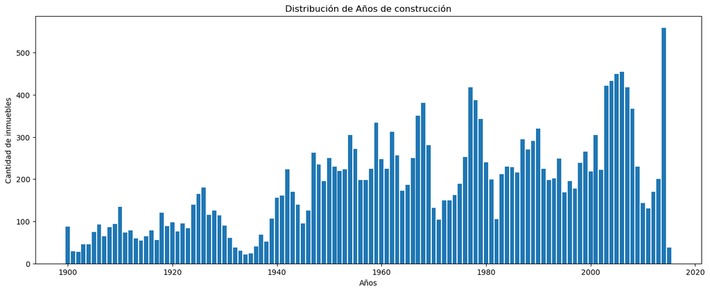

```python
# Tamaño de la gráfica
plt.figure(figsize=(16,6))

# Cantidad de apariciones de cada año de construcción
plot_data = data['Años'].value_counts()

# Valores únicos (años) y sus frecuencias
x = plot_data.index
y = plot_data.values

# Gráfico de barras
plt.bar(x,y)

# Títulos de los ejes y del gráfico
plt.xlabel("Años")
plt.ylabel("Cantidad de inmuebles")
plt.title('Distribución de Años de construcción')

# Mostrar la gráfica
plt.show()
```

Esta gráfica muestra la distribución de los años de construcción de inmuebles. En el eje X se muestran los años en que fueron construidas, mientras que en el eje Y se observa la cantidad de casas que se construyeron en cada año. De esta forma podemos identificar patrones, como los periodos en donde se tuvo un aumento en la construcción o los años en donde se tuvieron menores edificaciones.

Adicionalmente, podemos crear otros tipos de gráficos, como **histogramas**, que muestran la frecuencia de aparición de valores numéricos dentro de intervalos continuos. Este gráfico nos ayuda a analizar la distribución de una variable.

Para ello, usamos la siguiente función adicional a las mencionadas anteriormente:

- `hist()`: Esta función establece que se renderizará un histograma, como parámetro usa la variable a graficar y el número de intervalos (bins) en los que se dividirán los datos.

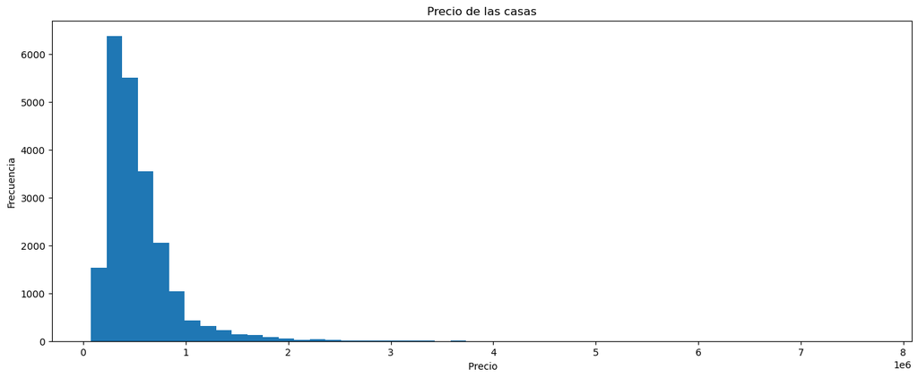

```python
# Tamaño de la gráfica
plt.figure(figsize=(16,6))

# Variable a graficar
x = data['Precio']

# Histograma
plt.hist(x, bins=50)

# Títulos de los ejes y de la gráfica
plt.xlabel(" Precio")
plt.ylabel("Frecuencia")
plt.title('Precio de las casas')

# Mostrar gráfica
plt.show()
```

Este histograma muestra la distribución de los precios de las casas. En el eje X tenemos los valores de precio (que están divididos en 50 intervalos y cuya escala es en millones), mientras que en el eje Y se encuentra la frecuencia con la que aparecen los precios en el conjunto de datos. Este gráfico nos ayuda a entender que la mayor parte de las casas se encuentra en un precio inferior a un millón.

Otra gráfica que ofrece esta librería es de **líneas o puntos**, que nos permite observar relaciones entre dos variables. Por ejemplo, analizaremos la relación entre el número de baños y el precio. La función `plot()` recibe estos argumentos:

- `data['Baños]`: Los datos que tendrá el eje X.
- `data['Precio]`: Los datos que incluirá el eje Y.
- `.`: Establece el formato a usarse, en este caso de puntos. Pero también se pueden usar otros, como `*` para estrellas o `o` para círculos.
- `color='blue'`: Color que tendrá la gráfica.

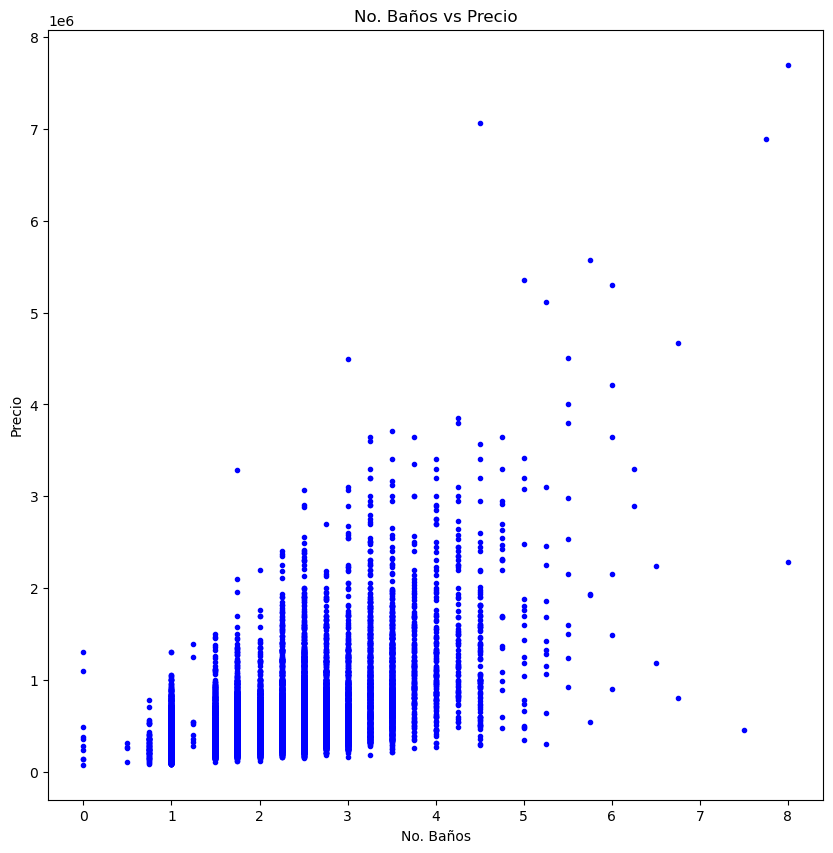

```python
plt.figure(figsize=(10,10))

x = data['Baños']
y = data['Precio']

plt.plot(x, y, '.', color='blue')
plt.title('No. Baños vs Precio')
plt.xlabel('No. Baños')
plt.ylabel('Precio')
plt.show()
```

Este gráfico nos permite ver una tendencia, la cual es que a medida que aumenta el número de baños, el precio tiende a ser mayor. Sin embargo, la dispersión es considerable lo que nos da a entender que el número de baños no es el único factor determinante, sino que existen otros factores que también influenciaron en el precio.

Matplotlib también nos permite realizar gráficos de **pie**, los cuales permiten representar la proporción de cada categoría dentro de un conjunto de datos. Cada región del círculo corresponde a una categoría distinta y su tamaño refleja el porcentaje que ocupa respecto al total. Para realizar este gráfico necesitamos la función `pie()` que es la encargada de generar el gráfico circular. Sus parámetros principales son:

- `Valores numéricos`: Indican el tamaño de cada sector (por ejemplo, la frecuencia de cada categoría).
- `labels`: Define las etiquetas que se mostrarán en cada sector (por ejemplo, el número de habitaciones).
- `autopct`: Muestra el porcentaje que representa cada categoría respecto al total.

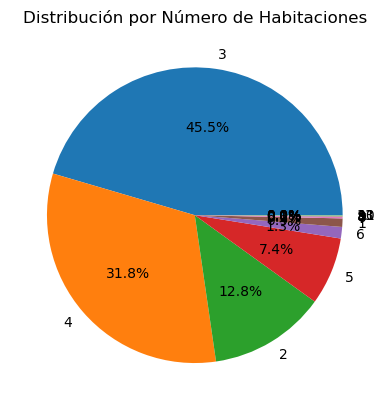

```python
# Obtener el número de valores de cada categoría
bedrooms_count = data['Cuartos'].value_counts()#.head(5)

# Función para ilustrar en forma de pie
plt.pie(bedrooms_count, labels=bedrooms_count.index, autopct='%1.1f%%')

# Título
plt.title('Distribución por Número de Habitaciones')

# Mostrar
plt.show()
```

Este gráfico nos permite comprender con mayor claridad la distribución de nuestro conjunto de datos. En particular, se observa que poco menos de la mitad de las viviendas cuentan con tres habitaciones, lo que representa una proporción significativa dentro del total.

#### **Ejercicio**

- Construir un gráfico que relacione los pisos con el número de habitaciones

```python
# TODO: Agrupa por 'Pisos' y calcula el promedio de 'Cuartos'

# TODO: Crea una nueva figura

# TODO: Dibuja las barras usando el índice como categorías y los valores como alturas

# TODO: Agrega un título diciente para el gráfico

# TODO: Nombra los ejes

# TODO: Muestra el gráfico.
```

### Seaborn

Al igual que con Matplotlib, la librería Seaborn también nos ayuda a crear visualizaciones para entender mejor nuestro dataset. Para crear un **histograma** necesitamos la función `histplot()`, que requiere de estos parámetros:

- `data[Precio]`: Datos ubicados en el eje X.
- `kde=True`: Este argumento permite dibujar una curva para comprender mejor la distribución de la variable.

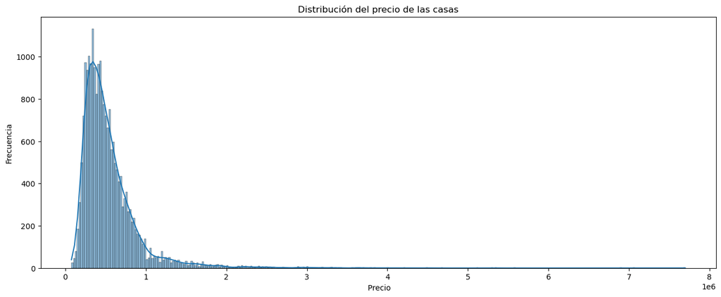

```python
# Crear gráfica con esas dimensiones
plt.figure(figsize=(16,6))

# Datos a usar
x = data['Precio']

# Título
plt.xlabel(" Precio")
plt.ylabel("Frecuencia")
plt.title('Distribución del precio de las casas')

# Histograma
sns.histplot(x=data['Precio'], kde=True)
```

Podemos ver que obtuvimos una gráfica bastante similar a la que teníamos anteriormente con Matplotlib, solo que esta no está tan agrupada como esa. En caso de que quisiéramos que la gráfica fuera exactamente igual, solo deberíamos agregar un tercer parámetro a la función: `histplot` que sería `bins=50`, que referencia a los intervalos en los que queremos que se agrupen los datos.

Una gráfica muy valiosa es el **Boxplot**, ya que nos permite separar una variable en cuartiles. La caja abarca los datos desde los cuartiles Q1 y Q3, mientras que los bigotes toman los valores mínimos y máximos que no se consideran outliers. Los puntos que podemos ver son los valores que estadísticamente se consideran atípicos. Para esto se usa la función `boxplot()`:

```python
sns.boxplot(x=data['AreaHabitable'])
```

[output not shown]

Otra gráfica que vamos a utilizar es la de **JointGrid**, la cual combina un gráfico en el centro que muestra la relación entre dos variables con histogramas en los ejes, este permite ver la correlación entre dos variables como sus distribuciones. Lo cual resulta útil para analizar las concentraciones y los patrones que los datos muestran. La función que se usa es: `jointgrid()`.

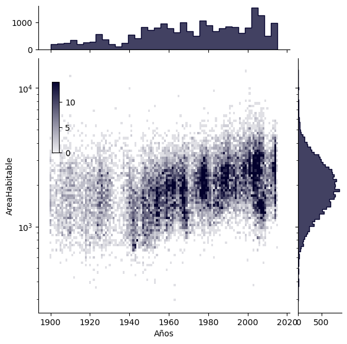

```python
# Cargar los datos
g = sns.JointGrid(data=data, x="Años", y="AreaHabitable", marginal_ticks=True)

# Escala logaritmica
g.ax_joint.set(yscale="log")

# Leyenda para la barra de colores
cax = g.figure.add_axes([.15, .55, .02, .2])

# Agregar histograma articular y marginal
g.plot_joint(
    sns.histplot, discrete=(True, False),
    cmap="light:#03012d", pmax=.8, cbar=True, cbar_ax=cax
)
g.plot_marginals(sns.histplot, element="step", color="#03012d")
```

En el gráfico central, los colores indican la densidad de puntos, en donde las zonas más oscuras representan áreas con mayor concentración. Se observa que las casas más recientes tiendes a ser más grandes, ya que antes de 1960 predominan las áreas más pequeñas, mientras que después de la década de los 80s se tienen construcciones con áreas mayores. Mientras que también se puede observar que después del 2000, las áreas empiezan a bajar como generalidad, aunque también hay que mencionar que durante ese periodo se tienen datos con mayor área.

#### **Ejercicio**

- Crea un boxplot en donde se muestre la distribución de precios por piso

```python
# TODO: Función boxplot con los datos de los ejes

# TODO: Título de la visualización

# TODO: Nombre del eje X

# TODO: Nombre del eje Y
```

## 6. Calidad de datos

Para analizar la calidad de los datos de un DataFrame podemos considerar distintos aspectos como lo son:

- Completitud.
- Unicidad.
- Consistencia.
- Validez.

En este notebook solo veremos los problemas que se pueden presentar más no sus posibles soluciones, lo cual será algo que exploraremos más adelante.

### Completitud

Es una dimensión en donde se mide el grado en el que un dataset contiene toda la información esperada, es decir que no tiene valores faltantes u omitidos.

```python
((data.isnull().sum()/data.shape[0])).sort_values(ascending=False)
```

```
Calificación       0.000278
Id                 0.000000
AreaHabitable15    0.000000
Longitud           0.000000
Latitud            0.000000
CodigoPostal       0.000000
Renovación         0.000000
Años               0.000000
AreaBase           0.000000
AreaSuperior       0.000000
Condición          0.000000
Fecha              0.000000
Vista              0.000000
FrenteMar          0.000000
Pisos              0.000000
AreaLote           0.000000
AreaHabitable      0.000000
Baños              0.000000
Cuartos            0.000000
Precio             0.000000
AreaLote15         0.000000
dtype: float64
```

Vemos que la única variable (columna) que tiene datos faltantes es `Calificación`.

Como primer acercamiento, veamos como son estos registros:

```python
# Filtrar filas con Calificación nula
nulos = data[data['Calificación'].isna()].copy()

print(f"Filas con Calificación nula: {nulos.shape[0]}")
indices = data.index[data['Calificación'].isna()]
data[data['Calificación'].isna()].copy().reset_index(drop=True)
```

```
Filas con Calificación nula: 6
```

|  | Id | Fecha | Precio | Cuartos | Baños | AreaHabitable | AreaLote | Pisos | FrenteMar | Vista | ... | Calificación | AreaSuperior | AreaBase | Años | Renovación | CodigoPostal | Latitud | Longitud | AreaHabitable15 | AreaLote15 |
| --- | --- | --- | --- | --- | --- | --- | --- | --- | --- | --- | --- | --- | --- | --- | --- | --- | --- | --- | --- | --- | --- |
| 0 | 7853210060 | 20150406T000000 | 430000.0 | 4 | 2.50 | 2070 | 4310 | 2.0 | NO | 0 | ... | NaN | 2070 | 0 | 2004 | 0 | 98065 | 475319.0 | -121.85 | 1970 | 3748 |
| 1 | 3668000070 | 20150105T000000 | 212000.0 | 3 | 1.75 | 1060 | 7875 | 1.0 | NO | 0 | ... | NaN | 1060 | 0 | 1986 | 0 | 98092 | 472761.0 | -122152.00 | 1420 | 7680 |
| 2 | 2424000060 | 20140616T000000 | 500000.0 | 4 | 2.75 | 2280 | 15347 | 1.0 | NO | 0 | ... | NaN | 2280 | 0 | 1960 | 0 | 98059 | 475218.0 | -122164.00 | 2280 | 15347 |
| 3 | 3677400445 | 20140902T000000 | 475000.0 | 3 | 1.50 | 2480 | 5280 | 1.5 | NO | 0 | ... | NaN | 1620 | 860 | 1947 | 0 | 98108 | 475575.0 | -122303.00 | 2090 | 4800 |
| 4 | 2470100110 | 20140804T000000 | 5570000.0 | 5 | 5.75 | 9200 | 35069 | 2.0 | NO | 0 | ... | NaN | 6200 | 3000 | 2001 | 0 | 98039 | 476289.0 | -122233.00 | 3560 | 24345 |
| 5 | 1068000375 | 20140923T000000 | 3200000.0 | 6 | 5.00 | 7100 | 18200 | 2.5 | NO | 0 | ... | NaN | 5240 | 1860 | 1933 | 2002 | 98199 | 476427.0 | -122408.00 | 3130 | 6477 |

6 rows × 21 columns

### Unicidad

Este atributo como su nombre lo sugiere indica que todos los registros están presentes una sola vez en el DataFrame, es decir, que no existen registros duplicados.

```python
data.duplicated(keep = False).sum()
```

```
0
```

Podemos ver que no existen registros duplicados. Esto nos dice que no hay una fila que sea exactamente igual a otra.

Pero podemos ir más allá, y ver si hay más de un registro con el mismo id, el cual debería ser único para cada dato:

```python
# ids duplicados
dup_counts = (data['Id'].value_counts()
                        .loc[lambda s: s > 1]
                        .sort_values(ascending=False))
for id_, n in dup_counts.items():
    print(f"Id={id_} → {n} apariciones")
```

```
Id=795000620 → 3 apariciones
Id=8651510380 → 2 apariciones
Id=3523069060 → 2 apariciones
Id=8832900780 → 2 apariciones
Id=526059224 → 2 apariciones
Id=5101405604 → 2 apariciones
Id=4139440480 → 2 apariciones
Id=5101402435 → 2 apariciones
Id=6021500970 → 2 apariciones
Id=9834200305 → 2 apariciones
Id=1237500540 → 2 apariciones
Id=2044500213 → 2 apariciones
Id=1523049207 → 2 apariciones
Id=7129304540 → 2 apariciones
Id=1254200015 → 2 apariciones
Id=9250900104 → 2 apariciones
Id=1219000473 → 2 apariciones
Id=2767602141 → 2 apariciones
Id=705730280 → 2 apariciones
Id=7409700215 → 2 apariciones
Id=2892700041 → 2 apariciones
Id=2724049222 → 2 apariciones
Id=3598600049 → 2 apariciones
Id=1568100300 → 2 apariciones
Id=8820903380 → 2 apariciones
Id=1823049202 → 2 apariciones
Id=7893805650 → 2 apariciones
Id=8910500150 → 2 apariciones
Id=4202400078 → 2 apariciones
Id=8807810890 → 2 apariciones
Id=3395040550 → 2 apariciones
Id=643300040 → 2 apariciones
Id=1250201165 → 2 apariciones
Id=9238500040 → 2 apariciones
Id=9828200460 → 2 apariciones
Id=2560801222 → 2 apariciones
Id=6751300375 → 2 apariciones
Id=3528000040 → 2 apariciones
Id=4345000510 → 2 apariciones
Id=726049190 → 2 apariciones
```

[output cut: 121 more lines]

```
Id=6308000010 → 2 apariciones
Id=7520000695 → 2 apariciones
Id=1825069031 → 2 apariciones
Id=4443800385 → 2 apariciones
Id=4154300296 → 2 apariciones
Id=5536100020 → 2 apariciones
Id=6117501820 → 2 apariciones
Id=2767603612 → 2 apariciones
Id=3578401060 → 2 apariciones
Id=641900050 → 2 apariciones
Id=3323059027 → 2 apariciones
Id=1630700361 → 2 apariciones
Id=1036400200 → 2 apariciones
Id=7856400240 → 2 apariciones
Id=6021501535 → 2 apariciones
```

Podemos ver que existen muchos ids compartidos por más de un registro, lo cual puede representar un problema, ya que el id, en principio, debería ser un identificador único para cada inmueble. Por lo que podemos profundizar y ver como están compuestos esos registros con id compartido.

```python
# Detalle de los registros
dup_table = (
    data[data['Id'].duplicated(keep=False)]
    .copy()
    .assign(repeticiones=data.groupby('Id')['Id'].transform('size'))
    .sort_values(['repeticiones', 'Id'], ascending=[False, True])
)

# Mostrar tabla
dup_table
```

|  | Id | Fecha | Precio | Cuartos | Baños | AreaHabitable | AreaLote | Pisos | FrenteMar | Vista | ... | AreaSuperior | AreaBase | Años | Renovación | CodigoPostal | Latitud | Longitud | AreaHabitable15 | AreaLote15 | repeticiones |
| --- | --- | --- | --- | --- | --- | --- | --- | --- | --- | --- | --- | --- | --- | --- | --- | --- | --- | --- | --- | --- | --- |
| 17602 | 795000620 | 20140924T000000 | 115000.0 | 3 | 1.0 | 1080 | 6250 | 1.0 | NO | 0 | ... | 1080 | 0 | 1950 | 0 | 98168 | 475045.0 | -122.33 | 1070 | 6250 | 3 |
| 17603 | 795000620 | 20141215T000000 | 124000.0 | 3 | 1.0 | 1080 | 6250 | 1.0 | NO | 0 | ... | 1080 | 0 | 1950 | 0 | 98168 | 475045.0 | -122.33 | 1070 | 6250 | 3 |
| 17604 | 795000620 | 20150311T000000 | 157000.0 | 3 | 1.0 | 1080 | 6250 | 1.0 | NO | 0 | ... | 1080 | 0 | 1950 | 0 | 98168 | 475045.0 | -122.33 | 1070 | 6250 | 3 |
| 2496 | 1000102 | 20140916T000000 | 280000.0 | 6 | 3.0 | 2400 | 9373 | 2.0 | NO | 0 | ... | 2400 | 0 | 1991 | 0 | 98002 | 473262.0 | -122214.00 | 2060 | 7316 | 2 |
| 2497 | 1000102 | 20150422T000000 | 300000.0 | 6 | 3.0 | 2400 | 9373 | 2.0 | NO | 0 | ... | 2400 | 0 | 1991 | 0 | 98002 | 473262.0 | -122214.00 | 2060 | 7316 | 2 |
| ... | ... | ... | ... | ... | ... | ... | ... | ... | ... | ... | ... | ... | ... | ... | ... | ... | ... | ... | ... | ... | ... |
| 6346 | 9828200460 | 20150106T000000 | 430000.0 | 2 | 1.0 | 700 | 4800 | 1.0 | NO | 0 | ... | 700 | 0 | 1922 | 0 | 98122 | 476147.0 | -122.30 | 1440 | 4800 | 2 |
| 15199 | 9834200305 | 20140716T000000 | 350000.0 | 3 | 1.0 | 1790 | 3876 | 1.5 | NO | 0 | ... | 1090 | 700 | 1904 | 0 | 98144 | 47575.0 | -122288.00 | 1360 | 4080 | 2 |
| 15200 | 9834200305 | 20150210T000000 | 615000.0 | 3 | 1.0 | 1790 | 3876 | 1.5 | NO | 0 | ... | 1090 | 700 | 1904 | 0 | 98144 | 47575.0 | -122288.00 | 1360 | 4080 | 2 |
| 1085 | 9834200885 | 20140717T000000 | 360000.0 | 4 | 2.5 | 2080 | 4080 | 1.0 | NO | 0 | ... | 1040 | 1040 | 1962 | 0 | 98144 | 47572.0 | -122.29 | 1340 | 4080 | 2 |
| 1086 | 9834200885 | 20150420T000000 | 550000.0 | 4 | 2.5 | 2080 | 4080 | 1.0 | NO | 0 | ... | 1040 | 1040 | 1962 | 0 | 98144 | 47572.0 | -122.29 | 1340 | 4080 | 2 |

353 rows × 22 columns

### Consistencia

```python
data['FrenteMar'].value_counts()
```

```
FrenteMar
NO    21446
SI      163
no        4
Name: count, dtype: int64
```

Este es el caso, como vemos tanto la cadena `NO` como la de `no` representan lo mismo, lo que significa un error de consistencia ya que tenemos más de una cadena para la misma información.

### Validez

Esta dimensión considera la exactitud y veracidad de la información, asegurando que los datos midan lo que se supone que deben medir y que sean correctos y coherentes. Es decir, que el valor que se tiene está dentro de los valores posibles.

```python
data.describe()
```

|  | Id | Precio | Cuartos | Baños | AreaHabitable | AreaLote | Pisos | Vista | Condición | Calificación | AreaSuperior | AreaBase | Años | Renovación | CodigoPostal | Latitud | Longitud | AreaHabitable15 | AreaLote15 |
| --- | --- | --- | --- | --- | --- | --- | --- | --- | --- | --- | --- | --- | --- | --- | --- | --- | --- | --- | --- |
| count | 2.161300e+04 | 2.161300e+04 | 21613.000000 | 21613.000000 | 21613.000000 | 2.161300e+04 | 21613.000000 | 21613.000000 | 21613.000000 | 21607.000000 | 21613.000000 | 21613.000000 | 21613.000000 | 21613.000000 | 21613.000000 | 21613.000000 | 21613.000000 | 21613.000000 | 21613.000000 |
| mean | 4.580302e+09 | 5.401822e+05 | 3.370842 | 2.114757 | 2079.899736 | 1.510697e+04 | 1.494309 | 0.247397 | 3.409430 | 7.656500 | 1788.390691 | 291.509045 | 1971.005136 | 84.402258 | 98077.939805 | 430610.744655 | -109898.947043 | 1986.552492 | 12768.455652 |
| std | 2.876566e+09 | 3.673622e+05 | 0.930062 | 0.770163 | 918.440897 | 4.142051e+04 | 0.539989 | 1.100329 | 0.650743 | 1.174463 | 828.090978 | 442.575043 | 29.373411 | 401.679240 | 53.505026 | 132157.751849 | 36768.975764 | 685.391304 | 27304.179631 |
| min | 1.000102e+06 | 7.500000e+04 | 0.000000 | 0.000000 | 290.000000 | 5.200000e+02 | 1.000000 | -3.000000 | 1.000000 | 1.000000 | 290.000000 | 0.000000 | 1900.000000 | 0.000000 | 98001.000000 | 47.190000 | -122519.000000 | 399.000000 | 651.000000 |
| 25% | 2.123049e+09 | 3.219500e+05 | 3.000000 | 1.750000 | 1427.000000 | 5.040000e+03 | 1.000000 | 0.000000 | 3.000000 | 7.000000 | 1190.000000 | 0.000000 | 1951.000000 | 0.000000 | 98033.000000 | 473849.000000 | -122318.000000 | 1490.000000 | 5100.000000 |
| 50% | 3.904930e+09 | 4.500000e+05 | 3.000000 | 2.250000 | 1910.000000 | 7.618000e+03 | 1.500000 | 0.000000 | 3.000000 | 7.000000 | 1560.000000 | 0.000000 | 1975.000000 | 0.000000 | 98065.000000 | 475524.000000 | -122205.000000 | 1840.000000 | 7620.000000 |
| 75% | 7.308900e+09 | 6.450000e+05 | 4.000000 | 2.500000 | 2550.000000 | 1.068800e+04 | 2.000000 | 0.000000 | 4.000000 | 8.000000 | 2210.000000 | 560.000000 | 1997.000000 | 0.000000 | 98118.000000 | 476694.000000 | -122062.000000 | 2360.000000 | 10083.000000 |
| max | 9.900000e+09 | 7.700000e+06 | 33.000000 | 8.000000 | 13540.000000 | 1.651359e+06 | 3.500000 | 44.000000 | 5.000000 | 13.000000 | 9410.000000 | 4820.000000 | 2015.000000 | 2015.000000 | 98199.000000 | 477776.000000 | -121.480000 | 6210.000000 | 871200.000000 |

Gracias a la función `.describe()` podemos ver que se tienen valores fuera del rango para la columna `Vista`, el diccionario menciona que el rango va de $[0,4]$ pero podemos ver que el valor mínimo es $-3$ y el valor máximo es $44$ lo cual no coincide con los valores que debería tomar, representando un problema de Validez.

### Formato automático para el entendimiento de los datos

Todo el proceso de entendimiento de datos que hemos realizadp a través de este notebook, se puede complementar con un reporte automático, el cual usa herramientas de pandas profiling.

Para cada variable del DataFrame genera las siguientes estadísticas:

1. Variables: Identifica todas las columnas que tiene el DataFrame.
2. Información importante: Muestra el tipo, valores únicos, valores faltantes.
3. Estadísticas: Refleja información importante como el valor mínimo, el máximo, número de valores que son cero, número de valores distintos (muy útil para ver si los ids solo están asociados a un registro) y faltantes (para ver si se cumple con la completitud).
4. Valores a considerar: Muestra los valores que más se repiten en una columna, estadísticas descriptivas y de cuartil, al igual que valores extremos.
5. Histogramas.

Tomado de la librería oficial de pandas_profiling en [github](https://github.com/pandas-profiling/pandas-profiling)

Lo más importante al utilizar esta librería es recordar que lo fundamental son los análisis que hagamos sobre estos reportes.

```python
%pip install ydata-profiling
```

Para verificar que se hizo la instalción correctamente, puedes utilizar:

```python
%pip show ydata-profiling
```

```python
from ydata_profiling import ProfileReport
```

```python
profile = ProfileReport(
    data,
    title="Reporte de Análisis Exploratorio",
    explorative=True
)
```

```python
profile.to_notebook_iframe()
```